# Final Project

## **Heart disease prediction from clinical features**

**Course:** Machine Learning and Deep Learning for Healthcare | M-D6410YE  
**Students:** Alessandro Carnio, Federico Panico

## Imports and paths

```python
import warnings
warnings.filterwarnings('ignore')

import numpy as np
import pandas as pd
import seaborn as sns
import matplotlib.pyplot as plt
from pathlib import Path

from sklearn.model_selection import (
    train_test_split,
    GroupKFold,
    cross_validate,
    cross_val_predict,
)
from sklearn.compose import ColumnTransformer
from sklearn.pipeline import Pipeline
from sklearn.preprocessing import StandardScaler, OneHotEncoder
from sklearn.impute import SimpleImputer

from sklearn.linear_model import LogisticRegression
from sklearn.naive_bayes import GaussianNB
from sklearn.tree import DecisionTreeClassifier
from sklearn.ensemble import RandomForestClassifier, GradientBoostingClassifier, StackingClassifier
from sklearn.svm import SVC
from sklearn.neural_network import MLPClassifier

from sklearn.metrics import (
    accuracy_score,
    f1_score,
    roc_auc_score,
    classification_report,
    brier_score_loss,
)
from sklearn.calibration import calibration_curve

sns.set_theme(style='whitegrid')
DATA_DIR = Path('data')
RANDOM_STATE = 42
```

## 1. Exploratory Data Analysis

We list files under `data/` and read the UCI notes so we know which processed file is recommended and what each column means.

```python
all_files = sorted([p for p in DATA_DIR.rglob('*') if p.is_file()])
file_table = pd.DataFrame({
    'file': [str(p.relative_to(DATA_DIR)) for p in all_files],
    'size_kb': [round(p.stat().st_size / 1024, 2) for p in all_files]
}).sort_values('size_kb', ascending=False)

file_table
```

|  | file | size_kb |
| --- | --- | --- |
| 14 | new.data | 380.64 |
| 11 | hungarian.data | 60.73 |
| 3 | cleveland.data | 59.25 |
| 13 | long-beach-va.data | 38.96 |
| 20 | switzerland.data | 24.10 |
| 2 | cleve.mod | 23.38 |
| 15 | processed.cleveland.data | 18.03 |
| 19 | reprocessed.hungarian.data | 10.80 |
| 16 | processed.hungarian.data | 10.02 |
| 10 | heart-disease.names | 9.82 |
| 18 | processed.va.data | 6.58 |
| 1 | bak | 6.58 |
| 17 | processed.switzerland.data | 4.01 |
| 8 | costs\heart-disease.README | 2.50 |
| 12 | Index | 0.63 |
| 0 | ask-detrano | 0.57 |
| 21 | WARNING | 0.40 |
| 6 | costs\heart-disease.expense | 0.27 |
| 9 | costs\Index | 0.24 |
| 5 | costs\heart-disease.delay | 0.23 |
| 4 | costs\heart-disease.cost | 0.18 |
| 7 | costs\heart-disease.group | 0.09 |

Processed `.data` files are small and ready to load; raw `.data` dumps are larger. For modelling we rely on the processed files, as the accompanying notes suggest.

```python
names_text = (DATA_DIR / 'heart-disease.names').read_text(encoding='utf-8', errors='ignore')
warning_text = (DATA_DIR / 'WARNING').read_text(encoding='utf-8', errors='ignore')

print('Excerpt from heart-disease.names (first lines):')
print('\n'.join(names_text.splitlines()[:22]))
print('\n' + '=' * 72 + '\n')
print('WARNING file:')
print(warning_text)
```

```
Excerpt from heart-disease.names (first lines):
Publication Request:
   >>>>>>>>>>>>>>>>>>>>>>>>>>>>>>>>>>>>>>>>>>>>>>>>>>>>>>>>>>>>>>>>>>>>>>
   This file describes the contents of the heart-disease directory.

   This directory contains 4 databases concerning heart disease diagnosis.
   All attributes are numeric-valued.  The data was collected from the
   four following locations:

     1. Cleveland Clinic Foundation (cleveland.data)
     2. Hungarian Institute of Cardiology, Budapest (hungarian.data)
     3. V.A. Medical Center, Long Beach, CA (long-beach-va.data)
     4. University Hospital, Zurich, Switzerland (switzerland.data)

   Each database has the same instance format.  While the databases have 76
   raw attributes, only 14 of them are actually used.  Thus I've taken the
   liberty of making 2 copies of each database: one with all the attributes
   and 1 with the 14 attributes actually used in past experiments.

   The authors of the databases have requested:

      ...that any publications resulting from the use of the data include the
      names of the principal investigator responsible for the data collection

========================================================================

WARNING file:
The file cleveland.data has been unfortunately messed up when we lost
node cip2 and loaded the file on node ics.  The file processed.cleveland.data
seems to be in good shape and is useable (for the 14 attributes situation).
I'll clean up cleveland.data as soon as possible.

Bad news: my original copy of the database appears to be corrupted.
I'll have to go back to the donor to get a new copy.

David Aha
```

The warning file tells us to avoid corrupted raw extracts and to prefer the processed Cleveland file for standard analyses. We keep that in mind when choosing Cleveland as the main single-centre benchmark.

The UCI heart disease studies use the same 14 input attributes plus the diagnosis label `num`.

```python
columns = [
    'age', 'sex', 'cp', 'trestbps', 'chol', 'fbs', 'restecg',
    'thalach', 'exang', 'oldpeak', 'slope', 'ca', 'thal', 'num'
]

numeric_cols = ['age', 'trestbps', 'chol', 'thalach', 'oldpeak']
categorical_cols = ['sex', 'cp', 'fbs', 'restecg', 'exang', 'slope', 'ca', 'thal']
pd.DataFrame({
    'name': columns,
    'type': ['numeric' if c in numeric_cols else ('label' if c == 'num' else 'categorical') for c in columns]
})
```

|  | name | type |
| --- | --- | --- |
| 0 | age | numeric |
| 1 | sex | categorical |
| 2 | cp | categorical |
| 3 | trestbps | numeric |
| 4 | chol | numeric |
| 5 | fbs | categorical |
| 6 | restecg | categorical |
| 7 | thalach | numeric |
| 8 | exang | categorical |
| 9 | oldpeak | numeric |
| 10 | slope | categorical |
| 11 | ca | categorical |
| 12 | thal | categorical |
| 13 | num | label |

We will impute and scale numerics, and impute plus one-hot encode categoricals. That matches the mixed data types and avoids treating coded categories as ordered numbers.

### 1.1 Loading all four processed sites

Each row is one patient; `num` is the severity label (0 = no disease, 1-4 = disease present with increasing severity). For binary classification we use presence vs absence: disease if `num > 0`.

```python
site_files = {
    'cleveland': 'processed.cleveland.data',
    'hungarian': 'processed.hungarian.data',
    'switzerland': 'processed.switzerland.data',
    'va': 'processed.va.data',
}

site_data = {}
for site, file_name in site_files.items():
    d = pd.read_csv(DATA_DIR / file_name, names=columns, header=None, na_values='?')
    d['site'] = site
    d['target_binary'] = (d['num'] > 0).astype(int)
    site_data[site] = d

full_processed = pd.concat(site_data.values(), ignore_index=True)
full_processed.shape
```

```
(920, 16)
```

```python
summary_rows = []
for site, d in site_data.items():
    summary_rows.append({
        'site': site,
        'rows': len(d),
        'missing_total': int(d[columns].isna().sum().sum()),
        'binary_positive_rate': round(d['target_binary'].mean(), 3),
        'num_mean': round(d['num'].mean(), 3),
    })

eda_site_summary = pd.DataFrame(summary_rows).sort_values('rows', ascending=False)
eda_site_summary
```

|  | site | rows | missing_total | binary_positive_rate | num_mean |
| --- | --- | --- | --- | --- | --- |
| 0 | cleveland | 303 | 6 | 0.459 | 0.937 |
| 1 | hungarian | 294 | 782 | 0.361 | 0.361 |
| 3 | va | 200 | 698 | 0.745 | 1.520 |
| 2 | switzerland | 123 | 273 | 0.935 | 1.805 |

Cleveland stands out with almost no missing fields; Hungarian, VA, and Switzerland have far more gaps. Positive rate also differs a lot by site, so pooling patients blindly mixes different populations and lab situations.

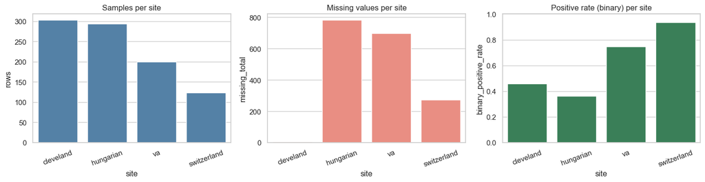

```python
fig, axes = plt.subplots(1, 3, figsize=(15, 4))

sns.barplot(data=eda_site_summary, x='site', y='rows', ax=axes[0], color='steelblue')
axes[0].set_title('Samples per site')

sns.barplot(data=eda_site_summary, x='site', y='missing_total', ax=axes[1], color='salmon')
axes[1].set_title('Missing values per site')

sns.barplot(data=eda_site_summary, x='site', y='binary_positive_rate', ax=axes[2], color='seagreen')
axes[2].set_title('Positive rate (binary) per site')
axes[2].set_ylim(0, 1)

for ax in axes:
    ax.tick_params(axis='x', rotation=20)

plt.tight_layout()
plt.show()
```

The bar plots shows this imbalance: Switzerland has very few rows but a very high positive rate compared with Hungarian data, for example. That is exactly why later we separate centres when we measure how well a model travels.

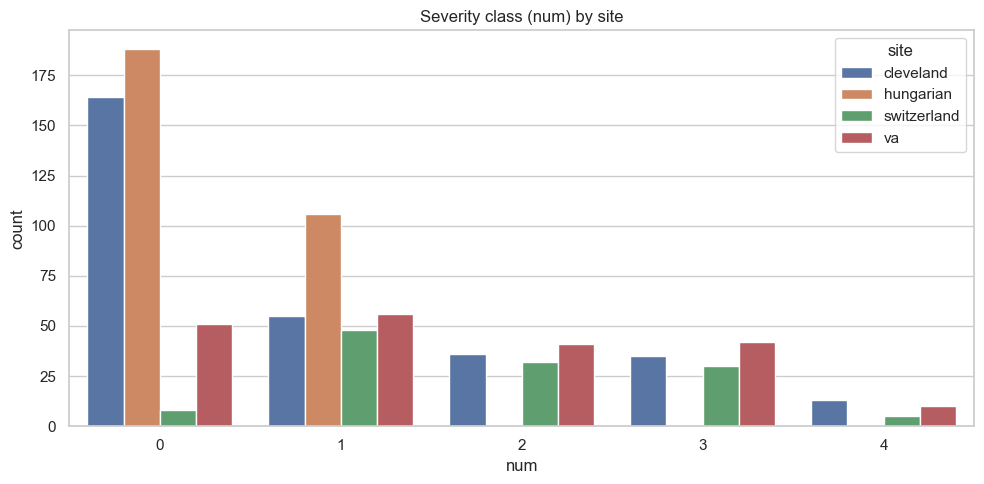

```python
plt.figure(figsize=(10, 5))
sns.countplot(data=full_processed, x='num', hue='site')
plt.title('Severity class (num) by site')
plt.tight_layout()
plt.show()
```

Severity classes are uneven and not equally represented across sites. Binary aggregation (`num > 0`) is what we use for the main classification task; multiclass severity would need even more care with class imbalance.

### 1.2 Cleeveland Site Analysis

We go deeper on Cleveland because it is the recommended processed subset, has minimal missingness, and matches what most papers report. The plots below are only for learning the data shape before fitting models.

```python
df = site_data['cleveland'].copy()

print('Shape:', df.shape)
print('\nMissing by column:')
print(df[columns].isna().sum().sort_values(ascending=False))
print('\nBinary target counts:')
print(df['target_binary'].value_counts())
print('\nSeverity (num) counts:')
print(df['num'].value_counts().sort_index())
```

```
Shape: (303, 16)

Missing by column:
ca          4
thal        2
cp          0
trestbps    0
age         0
sex         0
fbs         0
chol        0
restecg     0
thalach     0
oldpeak     0
exang       0
slope       0
num         0
dtype: int64

Binary target counts:
target_binary
0    164
1    139
Name: count, dtype: int64

Severity (num) counts:
num
0    164
1     55
2     36
3     35
4     13
Name: count, dtype: int64
```

Only a handful of cells are missing overall; most problems concentrate in `ca` and `thal`. The binary outcome is slightly tilted but still workable without aggressive resampling for a classroom baseline.

```python
df[numeric_cols].describe().T
```

|  | count | mean | std | min | 25% | 50% | 75% | max |
| --- | --- | --- | --- | --- | --- | --- | --- | --- |
| age | 303.0 | 54.438944 | 9.038662 | 29.0 | 48.0 | 56.0 | 61.0 | 77.0 |
| trestbps | 303.0 | 131.689769 | 17.599748 | 94.0 | 120.0 | 130.0 | 140.0 | 200.0 |
| chol | 303.0 | 246.693069 | 51.776918 | 126.0 | 211.0 | 241.0 | 275.0 | 564.0 |
| thalach | 303.0 | 149.607261 | 22.875003 | 71.0 | 133.5 | 153.0 | 166.0 | 202.0 |
| oldpeak | 303.0 | 1.039604 | 1.161075 | 0.0 | 0.0 | 0.8 | 1.6 | 6.2 |

Ranges look clinically plausible for this dataset; nothing stands out as an obvious data entry bug at this scale.

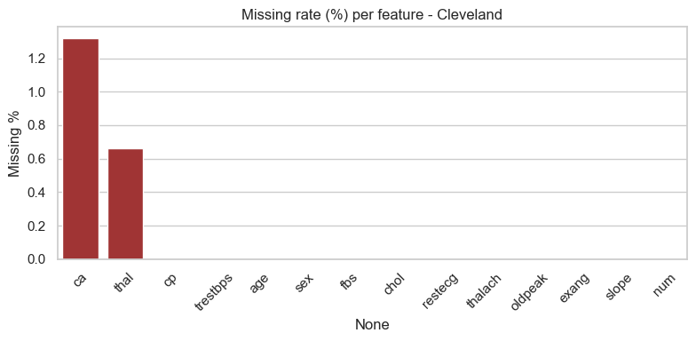

```python
missing_rate = (df[columns].isna().mean() * 100).sort_values(ascending=False)
plt.figure(figsize=(8, 4))
sns.barplot(x=missing_rate.index, y=missing_rate.values, color='firebrick')
plt.title('Missing rate (%) per feature - Cleveland')
plt.xticks(rotation=45)
plt.ylabel('Missing %')
plt.tight_layout()
plt.show()
```

Almost all gaps sit in two variables, which tells us where imputation matters most for Cleveland.

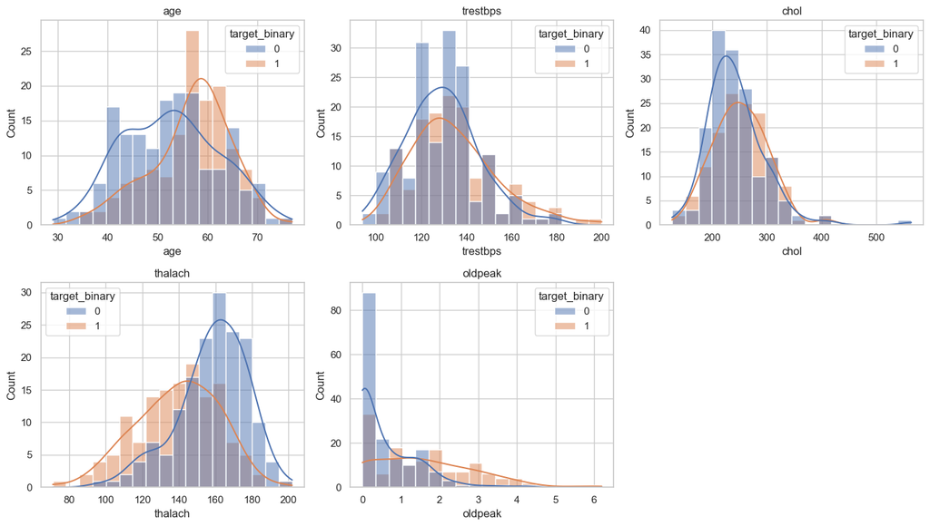

```python
fig, axes = plt.subplots(2, 3, figsize=(14, 8))
axes = axes.ravel()

for i, col in enumerate(numeric_cols):
    sns.histplot(data=df, x=col, hue='target_binary', kde=True, bins=18, ax=axes[i])
    axes[i].set_title(col)

axes[-1].axis('off')
plt.tight_layout()
plt.show()
```

Distributions overlap between classes, but some variables shift between healthy and disease; especially exercise-related signals, so there is signal for a learner.

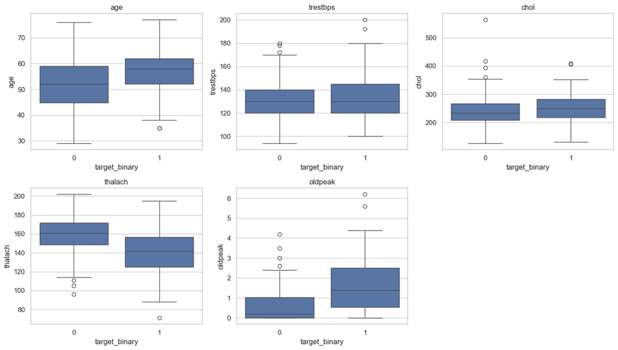

```python
fig, axes = plt.subplots(2, 3, figsize=(14, 8))
axes = axes.ravel()

for i, col in enumerate(numeric_cols):
    sns.boxplot(data=df, x='target_binary', y=col, ax=axes[i])
    axes[i].set_title(col)

axes[-1].axis('off')
plt.tight_layout()
plt.show()
```

Boxplots highlight separation and overlap at the same time; no single measurement separates the groups alone.

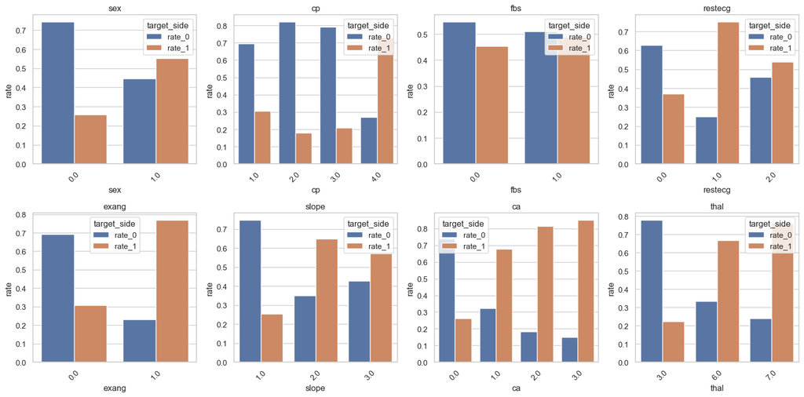

```python
fig, axes = plt.subplots(2, 4, figsize=(16, 8))
axes = axes.ravel()

for i, col in enumerate(categorical_cols):
    ctab = pd.crosstab(df[col], df['target_binary'], normalize='index').fillna(0)
    ctab.columns = ['rate_0', 'rate_1']
    ctab = ctab.reset_index().melt(id_vars=col, var_name='target_side', value_name='rate')
    sns.barplot(data=ctab, x=col, y='rate', hue='target_side', ax=axes[i])
    axes[i].set_title(col)
    axes[i].tick_params(axis='x', rotation=45)

plt.tight_layout()
plt.show()
```

Several categorical levels line up with higher disease rate, which supports encoding them properly instead of dropping them.

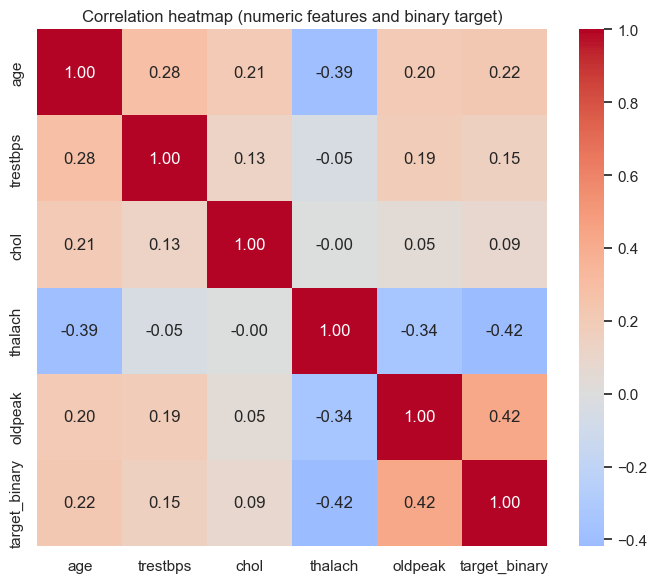

```python
corr = df[numeric_cols + ['target_binary']].corr(numeric_only=True)
plt.figure(figsize=(7, 6))
sns.heatmap(corr, annot=True, fmt='.2f', cmap='coolwarm', center=0)
plt.title('Correlation heatmap (numeric features and binary target)')
plt.tight_layout()
plt.show()
```

Correlations are moderate. We still expect gains from combining features in a model rather than using one variable in isolation.

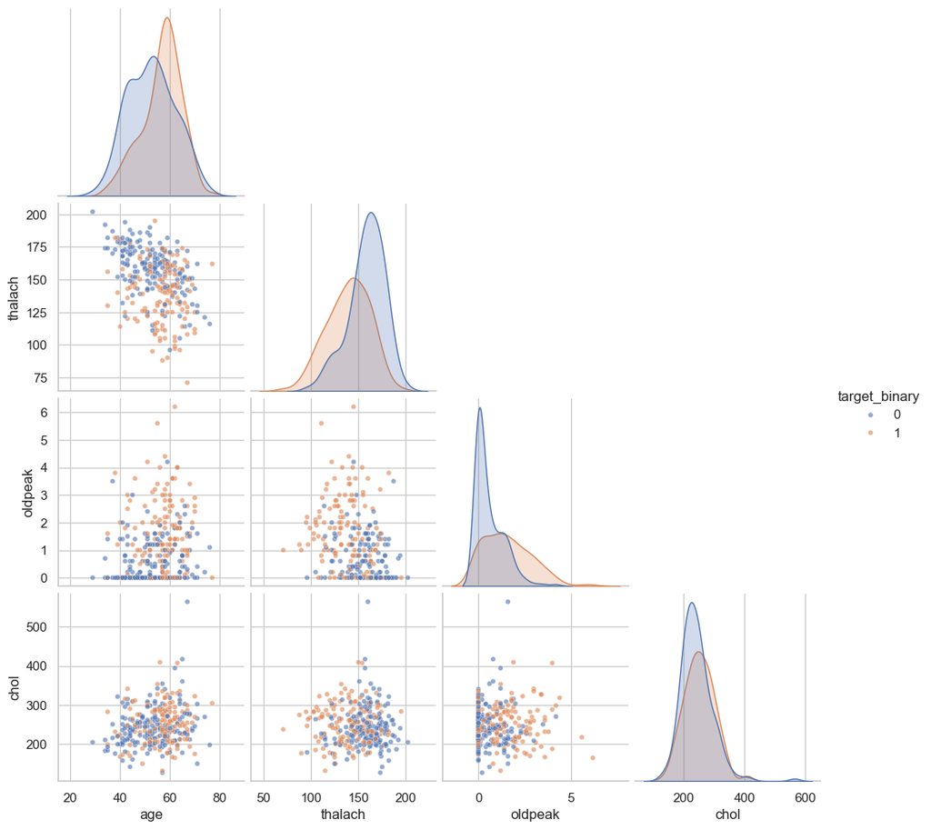

```python
pair_df = df[numeric_cols + ['target_binary']].dropna().copy()
sns.pairplot(
    pair_df,
    vars=['age', 'thalach', 'oldpeak', 'chol'],
    hue='target_binary',
    corner=True,
    plot_kws={'alpha': 0.6, 's': 18},
)
plt.show()
```

Pairwise scatter plots show partial separation with overlap, which matches the choice of both linear and flexible classifiers later on.

## 2. Models (Cleveland)

We fit models on Cleveland alone for a clear benchmark: same preprocessing as in standard homework setups, stratified train-test split, and several algorithms side by side including a stacking ensemble that combines logistic regression, random forest, and SVM. Cleveland is the natural choice here because it has the fewest missing values and matches the documentation.

The following steps drop the `site` column (every row is Cleveland) and build dense matrices after preprocessing for all sklearn estimators that expect numeric arrays.

```python
df_c = site_data['cleveland'].copy()
df_c['target_multiclass'] = df_c['num'].astype(int)

X_c = df_c.drop(columns=['num', 'target_binary', 'target_multiclass', 'site'])
y_c = df_c['target_binary']

num_pipe_c = Pipeline([
    ('imputer', SimpleImputer(strategy='median')),
    ('scaler', StandardScaler()),
])
cat_pipe_c = Pipeline([
    ('imputer', SimpleImputer(strategy='most_frequent')),
    ('onehot', OneHotEncoder(handle_unknown='ignore')),
])

preprocessor_c = ColumnTransformer([
    ('num', num_pipe_c, numeric_cols),
    ('cat', cat_pipe_c, categorical_cols),
])

Xc_train, Xc_test, yc_train, yc_test = train_test_split(
    X_c, y_c, test_size=0.2, stratify=y_c, random_state=RANDOM_STATE
)

Xc_train_pre = preprocessor_c.fit_transform(Xc_train)
Xc_test_pre = preprocessor_c.transform(Xc_test)

Xc_train_dense = Xc_train_pre.toarray() if hasattr(Xc_train_pre, 'toarray') else Xc_train_pre
Xc_test_dense = Xc_test_pre.toarray() if hasattr(Xc_test_pre, 'toarray') else Xc_test_pre

print('Train shape:', Xc_train_dense.shape, '| Test shape:', Xc_test_dense.shape)
```

```
Train shape: (242, 28) | Test shape: (61, 28)
```

Train and test share the same encoded feature space; the exact width depends on one-hot expansion for rare categories.

```python
models_c = {
    'Naive Bayes': GaussianNB(),
    'Logistic Regression': LogisticRegression(max_iter=2000, random_state=RANDOM_STATE),
    'Decision Tree': DecisionTreeClassifier(max_depth=5, random_state=RANDOM_STATE),
    'Random Forest': RandomForestClassifier(n_estimators=500, random_state=RANDOM_STATE),
    'Gradient Boosting': GradientBoostingClassifier(random_state=RANDOM_STATE),
    'SVM RBF': SVC(C=2.0, kernel='rbf', probability=True, random_state=RANDOM_STATE),
    'MLP': MLPClassifier(hidden_layer_sizes=(64, 32), max_iter=1500, random_state=RANDOM_STATE),
    'Stacking Ensemble': StackingClassifier(
        estimators=[
            ('lr', LogisticRegression(max_iter=2000, random_state=RANDOM_STATE)),
            ('rf', RandomForestClassifier(n_estimators=300, random_state=RANDOM_STATE)),
            ('svm', SVC(C=2.0, kernel='rbf', probability=True, random_state=RANDOM_STATE)),
        ],
        final_estimator=LogisticRegression(max_iter=2000, random_state=RANDOM_STATE),
        cv=5,
    ),
}

rows = []
fitted_c = {}
for name, model in models_c.items():
    model.fit(Xc_train_dense, yc_train)
    pred_train = model.predict(Xc_train_dense)
    pred_test = model.predict(Xc_test_dense)
    proba_train = model.predict_proba(Xc_train_dense)[:, 1]
    proba_test = model.predict_proba(Xc_test_dense)[:, 1]

    rows.append({
        'model': name,
        'train_acc': accuracy_score(yc_train, pred_train),
        'test_acc': accuracy_score(yc_test, pred_test),
        'train_auc': roc_auc_score(yc_train, proba_train),
        'test_auc': roc_auc_score(yc_test, proba_test),
        'test_f1': f1_score(yc_test, pred_test),
        'auc_gap_train_test': roc_auc_score(yc_train, proba_train) - roc_auc_score(yc_test, proba_test),
    })
    fitted_c[name] = model

bench_c = pd.DataFrame(rows).sort_values('test_auc', ascending=False)
bench_c
```

|  | model | train_acc | test_acc | train_auc | test_auc | test_f1 | auc_gap_train_test |
| --- | --- | --- | --- | --- | --- | --- | --- |
| 1 | Logistic Regression | 0.859504 | 0.885246 | 0.931229 | 0.966450 | 0.881356 | -0.035221 |
| 6 | MLP | 1.000000 | 0.885246 | 1.000000 | 0.965368 | 0.885246 | 0.034632 |
| 5 | SVM RBF | 0.929752 | 0.901639 | 0.978131 | 0.964286 | 0.896552 | 0.013845 |
| 7 | Stacking Ensemble | 0.929752 | 0.868852 | 0.988928 | 0.963203 | 0.866667 | 0.025724 |
| 4 | Gradient Boosting | 0.995868 | 0.868852 | 0.999519 | 0.946970 | 0.866667 | 0.052549 |
| 3 | Random Forest | 1.000000 | 0.868852 | 1.000000 | 0.941558 | 0.866667 | 0.058442 |
| 0 | Naive Bayes | 0.747934 | 0.721311 | 0.904855 | 0.826840 | 0.746269 | 0.078015 |
| 2 | Decision Tree | 0.925620 | 0.737705 | 0.979609 | 0.745130 | 0.724138 | 0.234480 |

On this split, logistic regression is at the top on AUC while tree models can show a larger gap between train and test AUC. The table is the place to compare numbers.

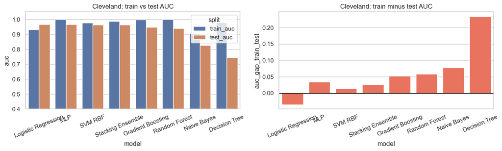

```python
fig, axes = plt.subplots(1, 2, figsize=(13, 4))

plot_auc = bench_c.melt(id_vars='model', value_vars=['train_auc', 'test_auc'], var_name='split', value_name='auc')
sns.barplot(data=plot_auc, x='model', y='auc', hue='split', ax=axes[0])
axes[0].set_title('Cleveland: train vs test AUC')
axes[0].tick_params(axis='x', rotation=22)
axes[0].set_ylim(0.4, 1.05)

sns.barplot(data=bench_c, x='model', y='auc_gap_train_test', color='tomato', ax=axes[1])
axes[1].axhline(0, color='black', linewidth=1)
axes[1].set_title('Cleveland: train minus test AUC')
axes[1].tick_params(axis='x', rotation=22)

plt.tight_layout()
plt.show()
```

The plots above show the difference between the train and the test auc, to asses overfitting or underfitting.

We pick the best model by test AUC on this table and print the classification report on the held-out Cleveland patients.

```python
best_c_name = bench_c.iloc[0]['model']
best_c_model = fitted_c[best_c_name]
best_c_pred = best_c_model.predict(Xc_test_dense)

print('Model with highest test AUC:', best_c_name)
print(classification_report(yc_test, best_c_pred, digits=3))
```

```
Model with highest test AUC: Logistic Regression
              precision    recall  f1-score   support

           0      0.933     0.848     0.889        33
           1      0.839     0.929     0.881        28

    accuracy                          0.885        61
   macro avg      0.886     0.889     0.885        61
weighted avg      0.890     0.885     0.885        61
```

The report gives precision and recall per class; useful if the clinical cost of false negatives differs from false positives.

## 3. Models (All sites)

Now we stack every processed centre into one table (`full_processed` already built above). Including `site` as a categorical input lets the model adjust for centre-specific effects during pooled training. That does not remove all shift-labels and protocols still differ; but it is a honest step before stricter checks.

We report three layers: a normal random split on the pooled data (optimistic if patients from the same hospital appear in both train and test), then `GroupKFold` with `K=4` so each fold holds one entire site out for validation while training on the other three, and finally leave-one-site-out summaries (same idea as repeating training four times with a different held-out centre). We also plot calibration for the strongest robust model by mean AUC and look at error rates by age and sex on the full pooled feature matrix after fitting that model.

```python
df_all = full_processed.copy()

X_m = df_all[[c for c in columns if c != 'num'] + ['site']].copy()
y_m = df_all['target_binary'].copy()
groups_m = df_all['site'].copy()

numeric_cols_m = numeric_cols
categorical_cols_m = categorical_cols + ['site']

num_pipe_m = Pipeline([
    ('imputer', SimpleImputer(strategy='median')),
    ('scaler', StandardScaler()),
])
cat_pipe_m = Pipeline([
    ('imputer', SimpleImputer(strategy='most_frequent')),
    ('onehot', OneHotEncoder(handle_unknown='ignore')),
])
preprocessor_m = ColumnTransformer([
    ('num', num_pipe_m, numeric_cols_m),
    ('cat', cat_pipe_m, categorical_cols_m),
])

models_m = {
    'Logistic Regression': LogisticRegression(max_iter=3000, random_state=RANDOM_STATE),
    'Random Forest': RandomForestClassifier(n_estimators=500, random_state=RANDOM_STATE),
    'Gradient Boosting': GradientBoostingClassifier(random_state=RANDOM_STATE),
    'SVM RBF': SVC(C=2.0, kernel='rbf', probability=True, random_state=RANDOM_STATE),
    'MLP': MLPClassifier(hidden_layer_sizes=(64, 32), max_iter=2000, random_state=RANDOM_STATE),
}

Xm_train, Xm_test, ym_train, ym_test = train_test_split(
    X_m, y_m, test_size=0.2, stratify=y_m, random_state=RANDOM_STATE
)

rows = []
for name, model in models_m.items():
    pipe = Pipeline([('prep', preprocessor_m), ('model', model)])
    pipe.fit(Xm_train, ym_train)
    pred = pipe.predict(Xm_test)
    proba = pipe.predict_proba(Xm_test)[:, 1]
    rows.append({
        'model': name,
        'test_acc': accuracy_score(ym_test, pred),
        'test_f1': f1_score(ym_test, pred),
        'test_auc': roc_auc_score(ym_test, proba),
        'brier': brier_score_loss(ym_test, proba),
    })

pooled_m = pd.DataFrame(rows).sort_values('test_auc', ascending=False)
pooled_m
```

|  | model | test_acc | test_f1 | test_auc | brier |
| --- | --- | --- | --- | --- | --- |
| 1 | Random Forest | 0.842391 | 0.859903 | 0.927786 | 0.107338 |
| 0 | Logistic Regression | 0.842391 | 0.862559 | 0.925514 | 0.106678 |
| 2 | Gradient Boosting | 0.858696 | 0.877358 | 0.921330 | 0.106412 |
| 3 | SVM RBF | 0.853261 | 0.874419 | 0.914395 | 0.107698 |
| 4 | MLP | 0.831522 | 0.851675 | 0.889168 | 0.156944 |

Random mixing usually produces strong-looking AUC because the model can learn hospital-specific cues that partially leak between train and test.

Now we can tighten the estimate:

```python
gkf = GroupKFold(n_splits=4)

group_rows = []
for name, model in models_m.items():
    pipe = Pipeline([('prep', preprocessor_m), ('model', model)])
    cv = cross_validate(
        pipe, X_m, y_m, groups=groups_m, cv=gkf,
        scoring=['roc_auc', 'f1', 'accuracy'], n_jobs=-1,
    )
    group_rows.append({
        'model': name,
        'gkf_auc_mean': cv['test_roc_auc'].mean(),
        'gkf_auc_std': cv['test_roc_auc'].std(),
        'gkf_f1_mean': cv['test_f1'].mean(),
        'gkf_acc_mean': cv['test_accuracy'].mean(),
    })

group_m = pd.DataFrame(group_rows).sort_values('gkf_auc_mean', ascending=False)
group_m.round(3)
```

|  | model | gkf_auc_mean | gkf_auc_std | gkf_f1_mean | gkf_acc_mean |
| --- | --- | --- | --- | --- | --- |
| 0 | Logistic Regression | 0.801 | 0.077 | 0.764 | 0.716 |
| 3 | SVM RBF | 0.793 | 0.085 | 0.810 | 0.779 |
| 1 | Random Forest | 0.791 | 0.078 | 0.770 | 0.723 |
| 2 | Gradient Boosting | 0.781 | 0.067 | 0.736 | 0.697 |
| 4 | MLP | 0.745 | 0.086 | 0.749 | 0.707 |

Mean AUC here is typically lower than the pooled table because validation never shares patients with training within the same fold hospital. Standard deviation tells you how much performance swings when the held-out centre changes.

```python
loso_rows = []
for test_site in sorted(df_all['site'].unique()):
    tr = df_all['site'] != test_site
    te = df_all['site'] == test_site
    Xtr, ytr = X_m.loc[tr], y_m.loc[tr]
    Xte, yte = X_m.loc[te], y_m.loc[te]

    for name, model in models_m.items():
        pipe = Pipeline([('prep', preprocessor_m), ('model', model)])
        pipe.fit(Xtr, ytr)
        pred = pipe.predict(Xte)
        proba = pipe.predict_proba(Xte)[:, 1]
        loso_rows.append({
            'heldout_site': test_site,
            'model': name,
            'auc': roc_auc_score(yte, proba),
            'f1': f1_score(yte, pred),
            'acc': accuracy_score(yte, pred),
        })

loso_m = pd.DataFrame(loso_rows)
robust_m = (
    loso_m.groupby('model')
    .agg(
        auc_mean=('auc', 'mean'),
        auc_std=('auc', 'std'),
        auc_min=('auc', 'min'),
        f1_mean=('f1', 'mean'),
        f1_min=('f1', 'min'),
    )
    .sort_values('auc_mean', ascending=False)
    .round(3)
)
robust_m
```

| model | auc_mean | auc_std | auc_min | f1_mean | f1_min |
| --- | --- | --- | --- | --- | --- |
| Logistic Regression | 0.801 | 0.089 | 0.716 | 0.764 | 0.728 |
| SVM RBF | 0.793 | 0.099 | 0.695 | 0.810 | 0.768 |
| Random Forest | 0.791 | 0.090 | 0.708 | 0.770 | 0.739 |
| Gradient Boosting | 0.781 | 0.077 | 0.692 | 0.736 | 0.721 |
| MLP | 0.745 | 0.099 | 0.654 | 0.749 | 0.700 |

The minimum AUC column is the pessimistic line: it answers how bad the score can get when the test hospital is the hardest for that model. That matters more for deployment stories than the average alone.

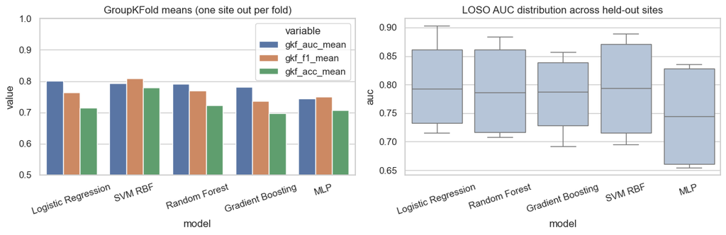

```python
fig, axes = plt.subplots(1, 2, figsize=(12, 4))
plot_df = group_m.melt(id_vars='model', value_vars=['gkf_auc_mean', 'gkf_f1_mean', 'gkf_acc_mean'])
sns.barplot(data=plot_df, x='model', y='value', hue='variable', ax=axes[0])
axes[0].set_ylim(0.5, 1.0)
axes[0].set_title('GroupKFold means (one site out per fold)')
axes[0].tick_params(axis='x', rotation=18)

sns.boxplot(data=loso_m, x='model', y='auc', color='lightsteelblue', ax=axes[1])
axes[1].set_title('LOSO AUC distribution across held-out sites')
axes[1].tick_params(axis='x', rotation=18)

plt.tight_layout()
plt.show()
```

The plot above compares the models using two validation methods: GroupKFold and LOSO (Leave-One-Site-Out).

The left chart shows the average AUC, F1-score, and accuracy for each model. The right chart shows how the AUC changes across different held-out sites in LOSO validation.

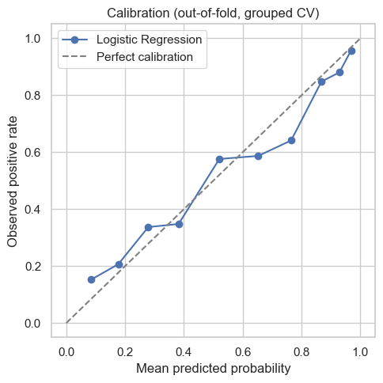

```
Model used: Logistic Regression
OOF Brier score: 0.1773
```

```python
best_m_name = robust_m.index[0]
best_m_model = models_m[best_m_name]
best_m_pipe = Pipeline([('prep', preprocessor_m), ('model', best_m_model)])

proba_oof = cross_val_predict(
    best_m_pipe, X_m, y_m, groups=groups_m, cv=gkf,
    method='predict_proba', n_jobs=-1,
)[:, 1]

frac_pos, mean_pred = calibration_curve(y_m, proba_oof, n_bins=10, strategy='quantile')

plt.figure(figsize=(5, 5))
plt.plot(mean_pred, frac_pos, marker='o', label=best_m_name)
plt.plot([0, 1], [0, 1], '--', color='gray', label='Perfect calibration')
plt.xlabel('Mean predicted probability')
plt.ylabel('Observed positive rate')
plt.title('Calibration (out-of-fold, grouped CV)')
plt.legend()
plt.tight_layout()
plt.show()

print('Model used:', best_m_name)
print('OOF Brier score:', round(brier_score_loss(y_m, proba_oof), 4))
```

If the curve sits close to the diagonal, predicted probabilities track observed frequencies within each bin. Large gaps would mean we should recalibrate before trusting risk numbers.

```python
best_m_pipe.fit(X_m, y_m)
pred_all = (best_m_pipe.predict_proba(X_m)[:, 1] >= 0.5).astype(int)

err = X_m[['age', 'sex', 'site']].copy()
err['y_true'] = y_m.values
err['y_pred'] = pred_all
err['error'] = (err['y_true'] != err['y_pred']).astype(int)
err['age_group'] = pd.cut(err['age'], bins=[0, 45, 55, 65, 100], labels=['<=45', '46-55', '56-65', '66+'])

error_summary = (
    err.groupby(['age_group', 'sex'])['error']
    .mean()
    .reset_index()
    .rename(columns={'error': 'error_rate'})
)
error_summary
```

|  | age_group | sex | error_rate |
| --- | --- | --- | --- |
| 0 | <=45 | 0.0 | 0.020833 |
| 1 | <=45 | 1.0 | 0.141892 |
| 2 | 46-55 | 0.0 | 0.120000 |
| 3 | 46-55 | 1.0 | 0.177686 |
| 4 | 56-65 | 0.0 | 0.214286 |
| 5 | 56-65 | 1.0 | 0.204461 |
| 6 | 66+ | 0.0 | 0.066667 |
| 7 | 66+ | 1.0 | 0.149254 |

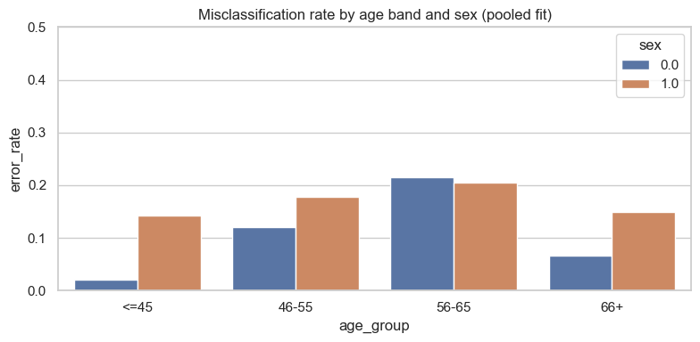

```python
plt.figure(figsize=(8, 4))
sns.barplot(data=error_summary, x='age_group', y='error_rate', hue='sex')
plt.ylim(0, 0.5)
plt.title('Misclassification rate by age band and sex (pooled fit)')
plt.tight_layout()
plt.show()
```

This plot shows the misclassification rate across different age groups and sex categories.

The highest error rate appears in the 56–65 age group for both sexes, meaning the model has more difficulty classifying subjects in this range. Younger subjects (less than 45) show the lowest error rate, especially for sex 0 (females). Overall, sex 1 (males) tends to have slightly higher misclassification rates across most age groups.

## 4. Conclusions

On the Cleveland subset, Logistic Regression achieved the best test AUC (0.97), while SVM obtained the best accuracy and F1-score (around 0.90).